# Sintomatología depresiva en personas con Ideación Suicida: Un análisis de redes

Pablo Ezequiel Flores Kanter, Berenice Piceda, Sol Gomez

9/1/2021

##—————————————————————————— ## Resumen 1. Descripción general de la muestra y datos recolectados. El trabajo se realizará en base a datos sobre sintomatología depresiva a partir de una muestra online de 4900 sujetos. Los datos de los distintos síntomas depresivos han sido obtenidos a partir de la aplicación de la escala Patient Health Questionnaire 9 (PHQ-9), un instrumento estandarizado de autoreporte que indaga sobre nueve síntomas depresivos diferentes. Para ello el instrumento se basa en los criterios diagnóstico diagnóstico para el Trastorno Depresivo Mayor que establece el Manual Diagnóstico y Estadístico de Trastornos Mentales en su quinta edición (DSM-V). La escala chequea la presencia de los siguientes síntomas en las pasadas últimas dos semanas: 1) ánimo deprimido; 2) anhedonia; 3) alteraciones en el sueño; 4) cansancio; 5) alteraciones en el apetito o en el peso; 6) sentimientos de culpa o inutilidad; 7) dificultades para concentrarse; 8) sentimientos de lentitud o preocupación; y 9) ideación suicida. Los ítems se responden en una escala de Likert desde 1 (nunca) a 5 (casi todos los días).

2. Análisis descriptivos.

-Analisis exploratorio general

-Matriz de correlación

-Prueba t

-Estimación de modelos de redes. El principal objetivo de éste trabajo es analizar cómo correlacionan los distíntos síntomas depresivos mencionados (sintomas del 1 (ánimo depresivo) al 8 (sentimientos de lentitud o preocupación)) en función de la variable ideaicón suicida (que se evalúa a partir del síntoma 9 de la escala PHQ-9). Para este objetivo se estimarán modelos de redes denominadas Markov random field o redes no-direccionales (undirected network/undirected graphical model) en dos grupos extremos de participantes distribuidos en base al item 9 de ideación suicida. Para esto se aplica un modelo de redes denominado Gaussian graphical model (GGM). En GGM cada elemento de la matriz de covarianza inversa corresponde a una conección (edge, aristas) en la red, la cual vincula dos variables (nodes, nodos) si se evidencia una interacción. Las aristas se estandarizan como coeficientes de correlación parcial entre dos variables luego de condicionarlas al resto de las variables del dataset. Con el objetivo de minimizar los errores estándares así como la inestabilidad de los parámetros estimados debido al overfitting (particularmente en muestras pequeñas), es que, en lugar de estimar la GGM directamente invirtiendo la matriz de varianza-covarianza, el modelo se estima utilizando Least Absolute Shrinkage and Selection Operator (LASSO). A los fines de comparar las redes entre los grupos extremos de interés es que se consideran las siguientes medidas de invarianza: invarianza estructural (network structure invariance), invarianza en la fuerza global de las correlaciones (global strength invariance), e invarianza al nivel de las correlaciones parciales entre dos nodos dados (edge invariance). En cada una de estas se aplican pruebas de hipótesis basadas en permutaciones (permutation based hypothesis test) para verificar si se aprecian o no diferencias estadísticamente significativas en cada una de las medidas de invarianza.

## Estructura de los datos

1. Análisis iniciales exploratorios: descriptivos y correlacionales. Para el caso de los análisis iniciales descriptivos y de correlación con variables sociodemográficas de sexo y edad se trasnformó levemente la tabla: A continuación se describen brevemente los datos y su estructura para este objetivo inicial de análisis (tidy data).
- Cuántas variables tienen? Se tienen cuatro variables, las cuales son : Sexo, Edad, Preguntas (sintomatología, items del PHQ-9) y Respuesta (las opciones de respuestas en escala likert).
- De qué tipo es cada variable? La variable “Sexo” puede ser int o boolean; “Edad” no tiene rango (int), “Preguntas” es un char y “Respuestas” es un int. Las variables “Preguntas” y “Respuestas” tienen un rango de 1 a 5.
- Cuántas observaciones? Se cuentan con 44181 observaciones, pero éstas se ven reducidas drásticamente al filtrarse los grupos principales, es decir, aquellos que estarían compuestos por las respuestas “1” (no ideación suicida) y “5” (ideación suicida). Es a éstas observaciones que se aplicará el análisis en base a la edad, al sexo, y a otras condiciones aún a definir.
2. Estimación de modelos de redes. Para este caso no fue pertinente llevar el dataset a un formato tidy similar al aplicado para los análisis iniciales. Esto es así debido a que cada síntoma depresivo se entiende como una variable diferente, que puede estar asociada con las restantes, pero que refiere a un atributo distintivo de la depresión. Más importante aún, el objetivo de la estimación de modelos de redes es verificar como estas distintas variables correlacionan entre sí, y si éstas correlaciones parciales entre ellas presentan alguna diferencia entre dos grupos independientes de participantes (aquellos con alta ideación suicida vs aquellos que no manifestaron ideación suicida). Por todo ello, en este caso se cuenta con 11 variables (edad, sexo, phq-1 al phq-8, y el item 9 del phq que sirve para generar los grupos extremos en esta variable referida a la ideación suicida). Sin embargo, para simplificar la base solo se consideró la variable de ideación suicida con los grupos ya generados (variable grupos extremos en el item 9 del phq, una variable nominal dicotómica, 0 = grupo no ideación suicida y 1 = grupo con ideación suicida) y los síntomas depresivos restantes (ítems 1 al 8 del PHQ-9, variables enteras con rango del 1 al 5). Esta base se denomina “phq.csv” en los análisis correspondientes, y contiene los datos de las 4909 observaciones.

##——————————————————————————- ## ANALISIS EXPLORATORIO- Reconocimiento de la Poblacion.

```r
#carga de datos generales
datos_totales <- read.csv("Base4900_on-line.csv", sep = ";", dec = ".", header = TRUE)
```

## Conversión de la tabla a tidy. Las preguntas ahora aparecen en una sola columna llamada “Preguntas”, y los valores de respuesta aparecen en una columna asociada llamada “Respuestas”.

##Ahora tendriamos 4 variables (sexo, edad, preguntas, respuestas)

```r
datos_totales_Tidy <- datos_totales %>% pivot_longer(c(PocoInteres,SensacionDeDepresion, ProblemasDeSuenio,
                                     SensacionDeCansancio, PocoApetito, SensacionDeFracaso,
                                     ProblemasDeConcentracion, AccionarLento, PensamientosSuicidas),
                                   names_to = "Preguntas", values_to = "Respuestas") %>% drop_na()
```

#Renombra nombre de variable Sexo a “Femenino” y “Masculino” #Resumen General de los datos originales

```r
datos_totales$Sexo <- factor(datos_totales$Sexo, labels=c("Femenino", "Masculino"))
datos_totales %>% skim()
```

Data summary

| Name | Piped data |
| --- | --- |
| Number of rows | 4909 |
| Number of columns | 11 |
| _______________________ |  |
| Column type frequency: |  |
| factor | 1 |
| numeric | 10 |
| ________________________ |  |
| Group variables | None |

**Variable type: factor**

| skim_variable | n_missing | complete_rate | ordered | n_unique | top_counts |
| --- | --- | --- | --- | --- | --- |
| Sexo | 0 | 1 | FALSE | 2 | Mas: 3358, Fem: 1551 |

**Variable type: numeric**

| skim_variable | n_missing | complete_rate | mean | sd | p0 | p25 | p50 | p75 | p100 | hist |
| --- | --- | --- | --- | --- | --- | --- | --- | --- | --- | --- |
| Edad | 0 | 1 | 27.14 | 9.86 | 10 | 21 | 23 | 31 | 81 | ▇▃▂▁▁ |
| PocoInteres | 0 | 1 | 3.10 | 1.37 | 1 | 2 | 3 | 4 | 5 | ▆▅▇▆▆ |
| SensacionDeDepresion | 0 | 1 | 3.38 | 1.45 | 1 | 2 | 4 | 5 | 5 | ▃▃▅▅▇ |
| ProblemasDeSuenio | 0 | 1 | 3.59 | 1.48 | 1 | 2 | 4 | 5 | 5 | ▃▂▃▃▇ |
| SensacionDeCansancio | 0 | 1 | 3.87 | 1.22 | 1 | 3 | 4 | 5 | 5 | ▁▂▃▅▇ |
| PocoApetito | 0 | 1 | 3.55 | 1.39 | 1 | 3 | 4 | 5 | 5 | ▃▂▅▅▇ |
| SensacionDeFracaso | 0 | 1 | 3.23 | 1.56 | 1 | 2 | 3 | 5 | 5 | ▆▃▃▅▇ |
| ProblemasDeConcentracion | 0 | 1 | 3.00 | 1.45 | 1 | 2 | 3 | 4 | 5 | ▇▆▇▆▇ |
| AccionarLento | 0 | 1 | 2.64 | 1.38 | 1 | 1 | 3 | 4 | 5 | ▇▅▇▃▃ |
| PensamientosSuicidas | 0 | 1 | 2.32 | 1.56 | 1 | 1 | 2 | 4 | 5 | ▇▂▂▂▃ |

#Resumen General de los datos en formato tidy

```r
datos_totales_Tidy$Sexo <- factor(datos_totales_Tidy$Sexo, labels=c("Femenino", "Masculino"))
datos_totales_Tidy %>% skim()
```

Data summary

| Name | Piped data |
| --- | --- |
| Number of rows | 44181 |
| Number of columns | 4 |
| _______________________ |  |
| Column type frequency: |  |
| character | 1 |
| factor | 1 |
| numeric | 2 |
| ________________________ |  |
| Group variables | None |

**Variable type: character**

| skim_variable | n_missing | complete_rate | min | max | empty | n_unique | whitespace |
| --- | --- | --- | --- | --- | --- | --- | --- |
| Preguntas | 0 | 1 | 11 | 24 | 0 | 9 | 0 |

**Variable type: factor**

| skim_variable | n_missing | complete_rate | ordered | n_unique | top_counts |
| --- | --- | --- | --- | --- | --- |
| Sexo | 0 | 1 | FALSE | 2 | Mas: 30222, Fem: 13959 |

**Variable type: numeric**

| skim_variable | n_missing | complete_rate | mean | sd | p0 | p25 | p50 | p75 | p100 | hist |
| --- | --- | --- | --- | --- | --- | --- | --- | --- | --- | --- |
| Edad | 0 | 1 | 27.14 | 9.86 | 10 | 21 | 23 | 31 | 81 | ▇▃▂▁▁ |
| Respuestas | 0 | 1 | 3.19 | 1.50 | 1 | 2 | 3 | 5 | 5 | ▆▃▆▅▇ |

#Grafico de la poblacion general en base a genero y edad

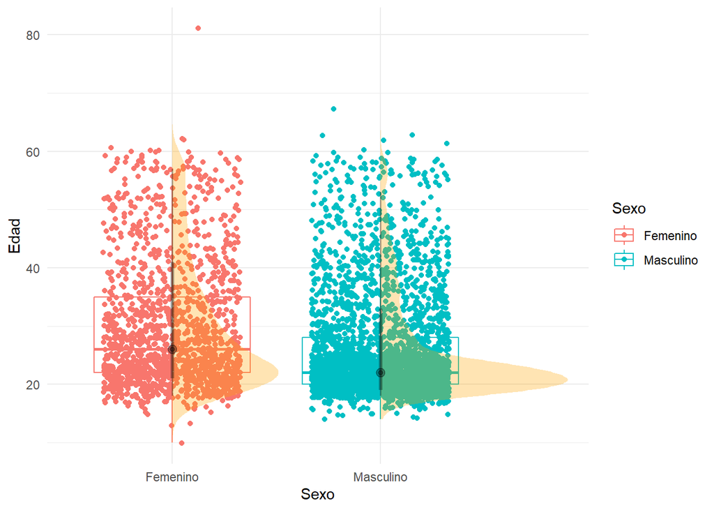

```r
datos_totales_GeneroYEdad <- datos_totales %>%
  ggplot(aes(x = Sexo, y = Edad, color = Sexo)) +
  geom_boxplot(outlier.shape = NA) +
  geom_jitter(width = 0.33) + theme_minimal() +
  stat_halfeye(color = "black", fill = "orange", alpha = 0.3)

datos_totales_GeneroYEdad
```

#Grafico General. Que respuesta gana en cada pregunta.

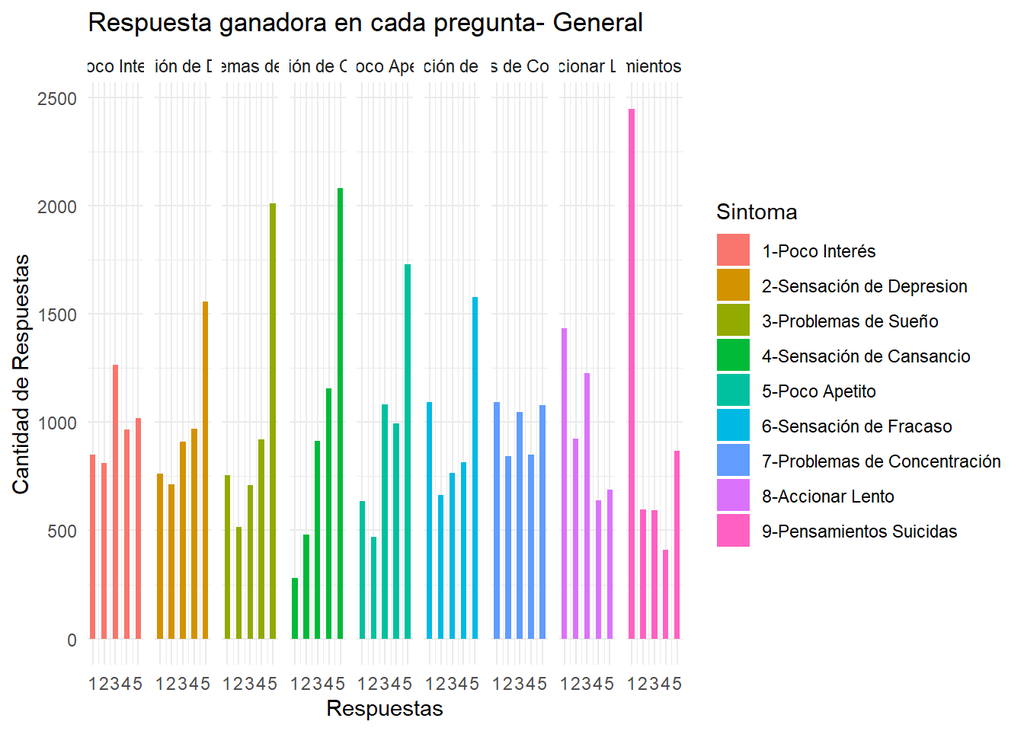

```r
datos_totales_Tidy_Pregunta9 <- datos_totales_Tidy %>%
  arrange(Preguntas) %>% filter(Preguntas == "PensamientosSuicidas") %>%
  group_by(Respuestas) %>%
  summarise(Cantidad_de_rtas = n()) %>%
  mutate(Sintoma = "9-Pensamientos Suicidas")

datos_totales_Tidy_Pregunta8 <- datos_totales_Tidy %>%
  arrange(Preguntas) %>% filter(Preguntas == "AccionarLento") %>%
  group_by(Respuestas) %>%
  summarise(Cantidad_de_rtas = n()) %>%
  mutate(Sintoma = "8-Accionar Lento")

datos_totales_Tidy_Pregunta7 <- datos_totales_Tidy %>%
  arrange(Preguntas) %>% filter(Preguntas == "ProblemasDeConcentracion") %>%
  group_by(Respuestas) %>%
  summarise(Cantidad_de_rtas = n()) %>%
  mutate(Sintoma = "7-Problemas de Concentración")

datos_totales_Tidy_Pregunta6 <- datos_totales_Tidy %>%
  arrange(Preguntas) %>% filter(Preguntas == "SensacionDeFracaso") %>%
  group_by(Respuestas) %>%
  summarise(Cantidad_de_rtas = n()) %>%
  mutate(Sintoma = "6-Sensación de Fracaso")

datos_totales_Tidy_Pregunta5 <- datos_totales_Tidy %>%
  arrange(Preguntas) %>% filter(Preguntas == "PocoApetito") %>%
  group_by(Respuestas) %>%
  summarise(Cantidad_de_rtas = n()) %>%
  mutate(Sintoma = "5-Poco Apetito")

datos_totales_Tidy_Pregunta4 <- datos_totales_Tidy %>%
  arrange(Preguntas) %>% filter(Preguntas == "SensacionDeCansancio") %>%
  group_by(Respuestas) %>%
  summarise(Cantidad_de_rtas = n()) %>%
  mutate(Sintoma = "4-Sensación de Cansancio")

datos_totales_Tidy_Pregunta3 <- datos_totales_Tidy %>%
  arrange(Preguntas) %>% filter(Preguntas == "ProblemasDeSuenio") %>%
  group_by(Respuestas) %>%
  summarise(Cantidad_de_rtas = n()) %>%
  mutate(Sintoma = "3-Problemas de Sueño")

datos_totales_Tidy_Pregunta2 <- datos_totales_Tidy %>%
  arrange(Preguntas) %>% filter(Preguntas == "SensacionDeDepresion") %>%
  group_by(Respuestas) %>%
  summarise(Cantidad_de_rtas = n()) %>%
  mutate(Sintoma = "2-Sensación de Depresion")

datos_totales_Tidy_Pregunta1 <- datos_totales_Tidy %>%
  arrange(Preguntas) %>% filter(Preguntas == "PocoInteres") %>%
  group_by(Respuestas) %>%
  summarise(Cantidad_de_rtas = n()) %>%
  mutate(Sintoma = "1-Poco Interés")

respuestas_por_pregunta <- rbind(datos_totales_Tidy_Pregunta1) %>%
  rbind(datos_totales_Tidy_Pregunta2) %>%
  rbind(datos_totales_Tidy_Pregunta3) %>%
  rbind(datos_totales_Tidy_Pregunta4) %>%
  rbind(datos_totales_Tidy_Pregunta5) %>%
  rbind(datos_totales_Tidy_Pregunta6) %>%
  rbind(datos_totales_Tidy_Pregunta7) %>%
  rbind(datos_totales_Tidy_Pregunta8) %>%
  rbind(datos_totales_Tidy_Pregunta9) %>%
  arrange(Sintoma)

respuestas_por_pregunta %>% ggplot + aes(x = Respuestas, y = Cantidad_de_rtas, fill = Sintoma) +
  geom_col(width = 0.5, position = position_dodge(2)) +
  labs(x = "Respuestas",
       y = "Cantidad de Respuestas",
       title = "Respuesta ganadora en cada pregunta- General") +
  theme_minimal() +
  facet_grid(. ~ Sintoma)
```

#——————————————————————————————— #Cantidad por Genero. Rango entre 15 y 20

[figure not shown]

```r
poblacion_entre15y20 <- datos_totales_Tidy %>% filter(Edad >= 15 & Edad <= 20)
poblacion_entre35y40 <- datos_totales_Tidy %>% filter(Edad >= 35 & Edad <= 40)
poblacion_entre55y60 <- datos_totales_Tidy %>% filter(Edad >= 55 & Edad <= 60)

numero_por_genero_entre15y20 <- poblacion_entre15y20 %>%
  group_by(Sexo) %>%
  summarise(Cantidad = n())
numero_por_genero_entre15y20 %>% ggplot(aes(x = Sexo, y = Cantidad)) +
  geom_col(colour = "black",
           fill = "#1380A1",
           width = 0.5) +
  labs(x = "Sexo",
       y = "Cantidad de Respuestas",
       title = "Población según género- 20 a 25 años") +
  theme_minimal()
```

#Cantidad por Genero. rango entre 35 y 40

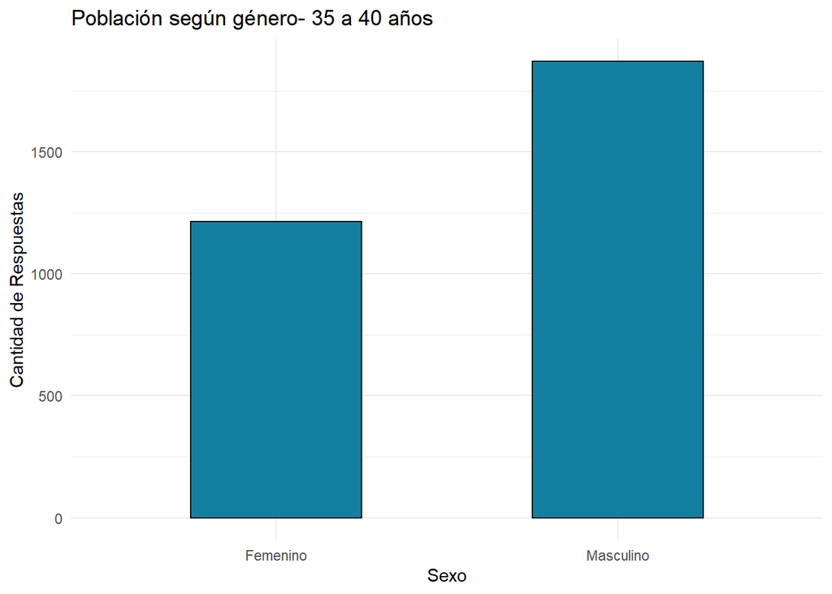

```r
numero_por_genero_entre35y40 <- poblacion_entre35y40 %>%
  group_by(Sexo) %>%
  summarise(Cantidad = n())
numero_por_genero_entre35y40 %>% ggplot(aes(x = Sexo, y = Cantidad)) +
  geom_col(colour = "black",
           fill = "#1380A1",
           width = 0.5) +
  labs(x = "Sexo",
       y = "Cantidad de Respuestas",
       title = "Población según género- 35 a 40 años") +
  theme_minimal()
```

#Cantidad por género. Rango entre 55 y 60

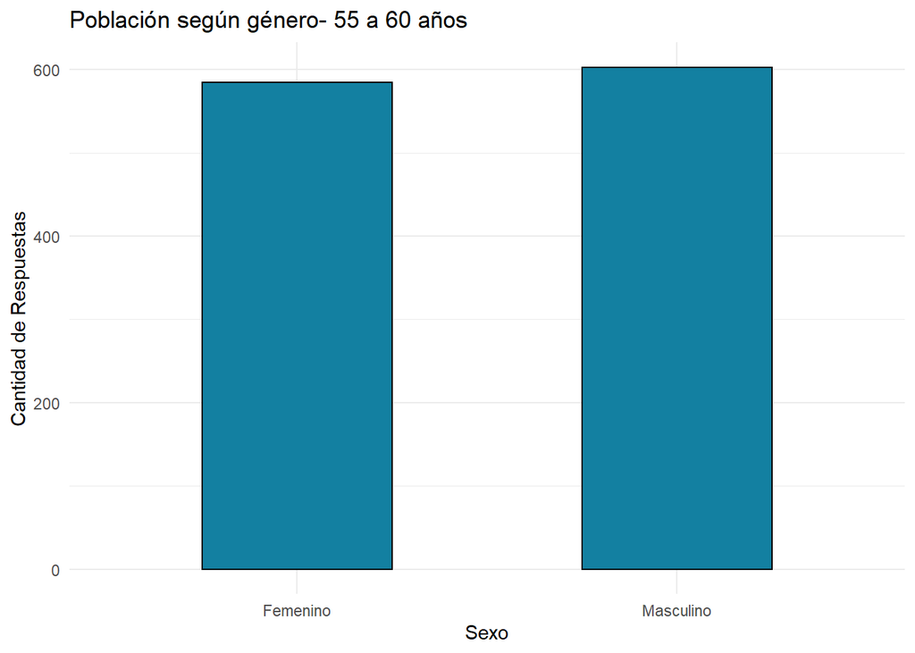

```r
numero_por_genero_entre55y60 <- poblacion_entre55y60 %>%
  group_by(Sexo) %>%
  summarise(Cantidad = n())
numero_por_genero_entre55y60 %>% ggplot(aes(x = Sexo, y = Cantidad)) +
  geom_col(colour = "black",
           fill = "#1380A1",
           width = 0.5) +
  labs(x = "Sexo",
       y = "Cantidad de Respuestas",
       title = "Población según género- 55 a 60 años") +
  theme_minimal()
```

#Grafico respuesta ganadora -Rango entre 15 y 20 años

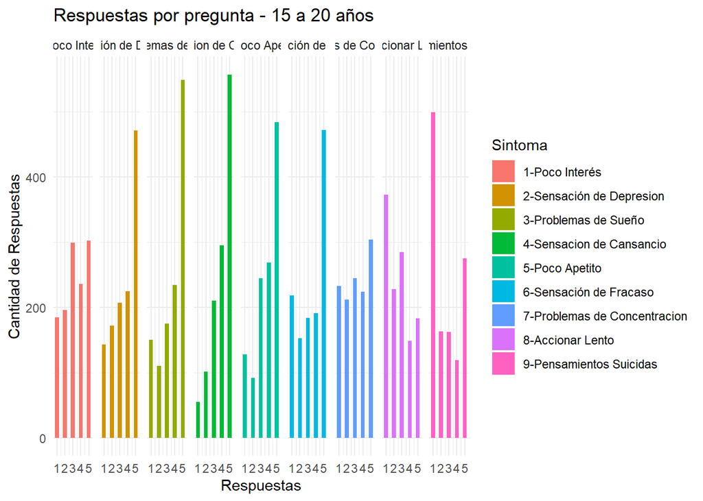

```r
poblacion_entre_15y20_Pregunta9 <- poblacion_entre15y20 %>%
  arrange(Preguntas) %>% filter(Preguntas == "PensamientosSuicidas") %>%
  group_by(Respuestas) %>%
  summarise(Cantidad_de_rtas = n()) %>%
  mutate(Sintoma = "9-Pensamientos Suicidas")

poblacion_entre_15y20_Pregunta8 <- poblacion_entre15y20 %>%
  arrange(Preguntas) %>% filter(Preguntas == "AccionarLento") %>%
  group_by(Respuestas) %>%
  summarise(Cantidad_de_rtas = n()) %>%
  mutate(Sintoma = "8-Accionar Lento")

poblacion_entre_15y20_Pregunta7 <- poblacion_entre15y20 %>%
  arrange(Preguntas) %>% filter(Preguntas == "ProblemasDeConcentracion") %>%
  group_by(Respuestas) %>%
  summarise(Cantidad_de_rtas = n()) %>%
  mutate(Sintoma = "7-Problemas de Concentracion")

poblacion_entre_15y20_Pregunta6 <- poblacion_entre15y20 %>%
  arrange(Preguntas) %>% filter(Preguntas == "SensacionDeFracaso") %>%
  group_by(Respuestas) %>%
  summarise(Cantidad_de_rtas = n()) %>%
  mutate(Sintoma = "6-Sensación de Fracaso")

poblacion_entre_15y20_Pregunta5 <- poblacion_entre15y20 %>%
  arrange(Preguntas) %>% filter(Preguntas == "PocoApetito") %>%
  group_by(Respuestas) %>%
  summarise(Cantidad_de_rtas = n()) %>%
  mutate(Sintoma = "5-Poco Apetito")

poblacion_entre_15y20_Pregunta4 <- poblacion_entre15y20 %>%
  arrange(Preguntas) %>% filter(Preguntas == "SensacionDeCansancio") %>%
  group_by(Respuestas) %>%
  summarise(Cantidad_de_rtas = n()) %>%
  mutate(Sintoma = "4-Sensacion de Cansancio")

poblacion_entre_15y20_Pregunta3 <- poblacion_entre15y20 %>%
  arrange(Preguntas) %>% filter(Preguntas == "ProblemasDeSuenio") %>%
  group_by(Respuestas) %>%
  summarise(Cantidad_de_rtas = n()) %>%
  mutate(Sintoma = "3-Problemas de Sueño")

poblacion_entre_15y20_Pregunta2 <- poblacion_entre15y20 %>%
  arrange(Preguntas) %>% filter(Preguntas == "SensacionDeDepresion") %>%
  group_by(Respuestas) %>%
  summarise(Cantidad_de_rtas = n()) %>%
  mutate(Sintoma = "2-Sensación de Depresion")

poblacion_entre_15y20_Pregunta1 <- poblacion_entre15y20 %>%
  arrange(Preguntas) %>% filter(Preguntas == "PocoInteres") %>%
  group_by(Respuestas) %>%
  summarise(Cantidad_de_rtas = n()) %>%
  mutate(Sintoma = "1-Poco Interés")

respuestas_por_pregunta_entre15y20 <- rbind(poblacion_entre_15y20_Pregunta1) %>%
  rbind(poblacion_entre_15y20_Pregunta2) %>%
  rbind(poblacion_entre_15y20_Pregunta3) %>%
  rbind(poblacion_entre_15y20_Pregunta4) %>%
  rbind(poblacion_entre_15y20_Pregunta5) %>%
  rbind(poblacion_entre_15y20_Pregunta6) %>%
  rbind(poblacion_entre_15y20_Pregunta7) %>%
  rbind(poblacion_entre_15y20_Pregunta8) %>%
  rbind(poblacion_entre_15y20_Pregunta9) %>%
  arrange(Sintoma)

respuestas_por_pregunta_entre15y20 %>%
  ggplot(aes(x = Respuestas, y = Cantidad_de_rtas, fill = Sintoma)) +
  geom_col(width = 0.5) +
  labs(x = "Respuestas",
       y = "Cantidad de Respuestas",
       title = "Respuestas por pregunta - 15 a 20 años") +
  theme_minimal() +
  facet_grid(. ~ Sintoma)
```

#Grafico respuesta ganadora -Rango entre 35 y 40 años

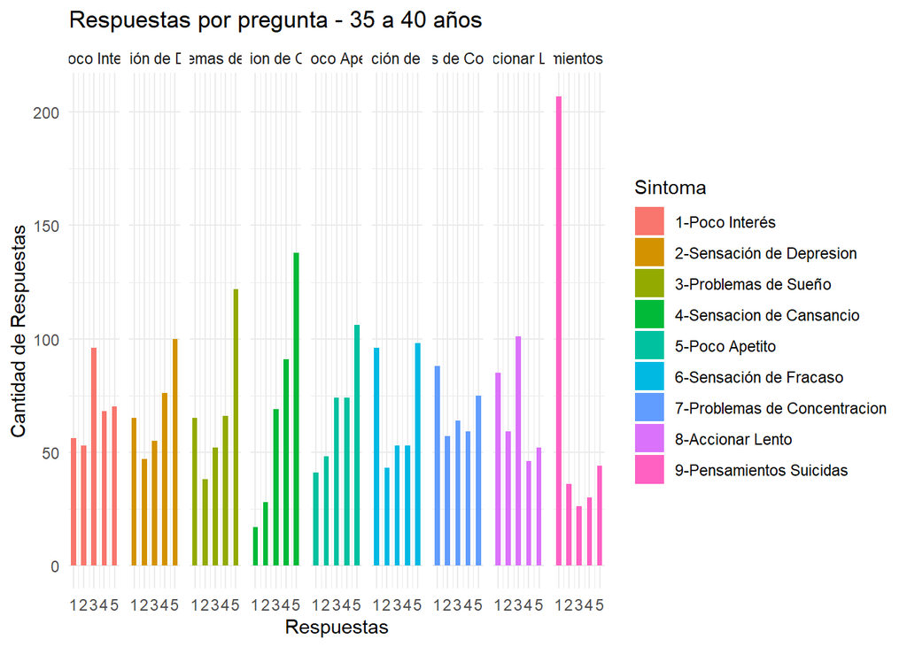

```r
poblacion_entre_35y40_Pregunta9 <- poblacion_entre35y40 %>%
  arrange(Preguntas) %>% filter(Preguntas == "PensamientosSuicidas") %>%
  group_by(Respuestas) %>%
  summarise(Cantidad_de_rtas = n()) %>%
  mutate(Sintoma = "9-Pensamientos Suicidas")

poblacion_entre_35y40_Pregunta8 <- poblacion_entre35y40 %>%
  arrange(Preguntas) %>% filter(Preguntas == "AccionarLento") %>%
  group_by(Respuestas) %>%
  summarise(Cantidad_de_rtas = n()) %>%
  mutate(Sintoma = "8-Accionar Lento")

poblacion_entre_35y40_Pregunta7 <- poblacion_entre35y40 %>%
  arrange(Preguntas) %>% filter(Preguntas == "ProblemasDeConcentracion") %>%
  group_by(Respuestas) %>%
  summarise(Cantidad_de_rtas = n()) %>%
  mutate(Sintoma = "7-Problemas de Concentracion")

poblacion_entre_35y40_Pregunta6 <- poblacion_entre35y40 %>%
  arrange(Preguntas) %>% filter(Preguntas == "SensacionDeFracaso") %>%
  group_by(Respuestas) %>%
  summarise(Cantidad_de_rtas = n()) %>%
  mutate(Sintoma = "6-Sensación de Fracaso")

poblacion_entre_35y40_Pregunta5 <- poblacion_entre35y40 %>%
  arrange(Preguntas) %>% filter(Preguntas == "PocoApetito") %>%
  group_by(Respuestas) %>%
  summarise(Cantidad_de_rtas = n()) %>%
  mutate(Sintoma = "5-Poco Apetito")

poblacion_entre_35y40_Pregunta4 <- poblacion_entre35y40 %>%
  arrange(Preguntas) %>% filter(Preguntas == "SensacionDeCansancio") %>%
  group_by(Respuestas) %>%
  summarise(Cantidad_de_rtas = n()) %>%
  mutate(Sintoma = "4-Sensacion de Cansancio")

poblacion_entre_35y40_Pregunta3 <- poblacion_entre35y40 %>%
  arrange(Preguntas) %>% filter(Preguntas == "ProblemasDeSuenio") %>%
  group_by(Respuestas) %>%
  summarise(Cantidad_de_rtas = n()) %>%
  mutate(Sintoma = "3-Problemas de Sueño")

poblacion_entre_35y40_Pregunta2 <- poblacion_entre35y40 %>%
  arrange(Preguntas) %>% filter(Preguntas == "SensacionDeDepresion") %>%
  group_by(Respuestas) %>%
  summarise(Cantidad_de_rtas = n()) %>%
  mutate(Sintoma = "2-Sensación de Depresion")

poblacion_entre_35y40_Pregunta1 <- poblacion_entre35y40 %>%
  arrange(Preguntas) %>% filter(Preguntas == "PocoInteres") %>%
  group_by(Respuestas) %>%
  summarise(Cantidad_de_rtas = n()) %>%
  mutate(Sintoma = "1-Poco Interés")

respuestas_por_pregunta_entre35y40 <- rbind(poblacion_entre_35y40_Pregunta1) %>%
  rbind(poblacion_entre_35y40_Pregunta2) %>%
  rbind(poblacion_entre_35y40_Pregunta3) %>%
  rbind(poblacion_entre_35y40_Pregunta4) %>%
  rbind(poblacion_entre_35y40_Pregunta5) %>%
  rbind(poblacion_entre_35y40_Pregunta6) %>%
  rbind(poblacion_entre_35y40_Pregunta7) %>%
  rbind(poblacion_entre_35y40_Pregunta8) %>%
  rbind(poblacion_entre_35y40_Pregunta9) %>%
  arrange(Sintoma)

respuestas_por_pregunta_entre35y40 %>%
  ggplot(aes(x = Respuestas, y = Cantidad_de_rtas, fill = Sintoma)) +
  geom_col(width = 0.5) +
  labs(x = "Respuestas",
       y = "Cantidad de Respuestas",
       title = "Respuestas por pregunta - 35 a 40 años") +
  theme_minimal() +
  facet_grid(. ~ Sintoma)
```

#Grafico respuesta ganadora -Rango entre 55 y 60 años

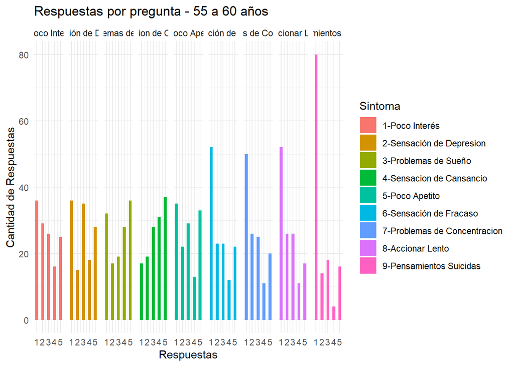

```r
poblacion_entre_55y60_Pregunta9 <- poblacion_entre55y60 %>%
  arrange(Preguntas) %>% filter(Preguntas == "PensamientosSuicidas") %>%
  group_by(Respuestas) %>%
  summarise(Cantidad_de_rtas = n()) %>%
  mutate(Sintoma = "9-Pensamientos Suicidas")

poblacion_entre_55y60_Pregunta8 <- poblacion_entre55y60 %>%
  arrange(Preguntas) %>% filter(Preguntas == "AccionarLento") %>%
  group_by(Respuestas) %>%
  summarise(Cantidad_de_rtas = n()) %>%
  mutate(Sintoma = "8-Accionar Lento")

poblacion_entre_55y60_Pregunta7 <- poblacion_entre55y60 %>%
  arrange(Preguntas) %>% filter(Preguntas == "ProblemasDeConcentracion") %>%
  group_by(Respuestas) %>%
  summarise(Cantidad_de_rtas = n()) %>%
  mutate(Sintoma = "7-Problemas de Concentracion")

poblacion_entre_55y60_Pregunta6 <- poblacion_entre55y60 %>%
  arrange(Preguntas) %>% filter(Preguntas == "SensacionDeFracaso") %>%
  group_by(Respuestas) %>%
  summarise(Cantidad_de_rtas = n()) %>%
  mutate(Sintoma = "6-Sensación de Fracaso")

poblacion_entre_55y60_Pregunta5 <- poblacion_entre55y60 %>%
  arrange(Preguntas) %>% filter(Preguntas == "PocoApetito") %>%
  group_by(Respuestas) %>%
  summarise(Cantidad_de_rtas = n()) %>%
  mutate(Sintoma = "5-Poco Apetito")

poblacion_entre_55y60_Pregunta4 <- poblacion_entre55y60 %>%
  arrange(Preguntas) %>% filter(Preguntas == "SensacionDeCansancio") %>%
  group_by(Respuestas) %>%
  summarise(Cantidad_de_rtas = n()) %>%
  mutate(Sintoma = "4-Sensacion de Cansancio")

poblacion_entre_55y60_Pregunta3 <- poblacion_entre55y60 %>%
  arrange(Preguntas) %>% filter(Preguntas == "ProblemasDeSuenio") %>%
  group_by(Respuestas) %>%
  summarise(Cantidad_de_rtas = n()) %>%
  mutate(Sintoma = "3-Problemas de Sueño")

poblacion_entre_55y60_Pregunta2 <- poblacion_entre55y60 %>%
  arrange(Preguntas) %>% filter(Preguntas == "SensacionDeDepresion") %>%
  group_by(Respuestas) %>%
  summarise(Cantidad_de_rtas = n()) %>%
  mutate(Sintoma = "2-Sensación de Depresion")

poblacion_entre_55y60_Pregunta1 <- poblacion_entre55y60 %>%
  arrange(Preguntas) %>% filter(Preguntas == "PocoInteres") %>%
  group_by(Respuestas) %>%
  summarise(Cantidad_de_rtas = n()) %>%
  mutate(Sintoma = "1-Poco Interés")

respuestas_por_pregunta_entre55y60 <- rbind(poblacion_entre_55y60_Pregunta1) %>%
  rbind(poblacion_entre_55y60_Pregunta2) %>%
  rbind(poblacion_entre_55y60_Pregunta3) %>%
  rbind(poblacion_entre_55y60_Pregunta4) %>%
  rbind(poblacion_entre_55y60_Pregunta5) %>%
  rbind(poblacion_entre_55y60_Pregunta6) %>%
  rbind(poblacion_entre_55y60_Pregunta7) %>%
  rbind(poblacion_entre_55y60_Pregunta8) %>%
  rbind(poblacion_entre_55y60_Pregunta9) %>%
  arrange(Sintoma)

respuestas_por_pregunta_entre55y60 %>%
  ggplot(aes(x = Respuestas, y = Cantidad_de_rtas, fill = Sintoma)) +
  geom_col(width = 0.5) +
  labs(x = "Respuestas",
       y = "Cantidad de Respuestas",
       title = "Respuestas por pregunta - 55 a 60 años") +
  theme_minimal() +
  facet_grid(. ~ Sintoma)
```

#—————————————————————————————— #IDEACION SUICIDA EN GENERAL #Filtro para respuesta 9 - Ideación suicida

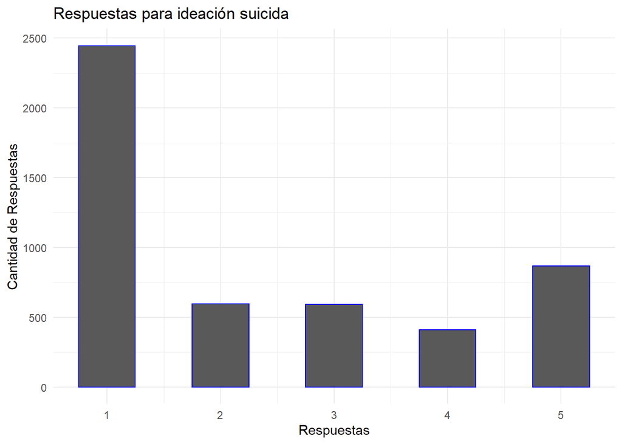

```r
pensamiento_suicida <- datos_totales_Tidy %>%
  filter(Preguntas == "PensamientosSuicidas") %>%
  group_by(Respuestas) %>%
  summarise(Cantidad = n())

pensamiento_suicida %>% ggplot(aes(x = Respuestas, y = Cantidad)) +
  geom_col(width = 0.5, color = "blue") +
  labs(x = "Respuestas",
       y = "Cantidad de Respuestas",
       title = "Respuestas para ideación suicida") +
  theme_minimal()
```

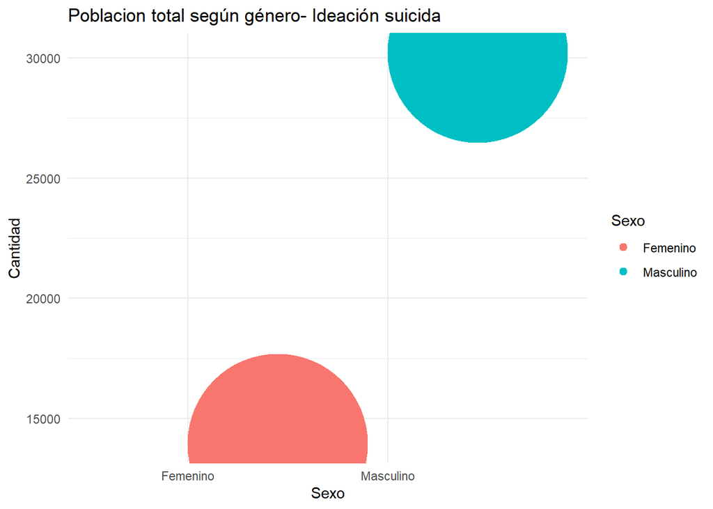

```r
respuesta_5_en_todas <- datos_totales_Tidy %>%
  group_by(Sexo) %>%
  summarise(Cantidad = n())

respuesta_5_en_todas %>% ggplot(aes(x = Sexo, y = Cantidad, color = Sexo, fill = Sexo)) +
  geom_dots() +
  labs(title = "Poblacion total según género- Ideación suicida") +
  theme_minimal()
```

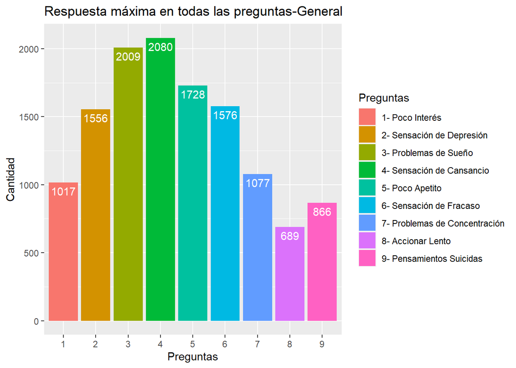

```r
respuesta_5_en_todas <- datos_totales_Tidy %>%
  filter(Respuestas == 5) %>%
  arrange(Preguntas) %>%
  group_by(Preguntas) %>%
  summarise(Cantidad = n())
respuesta_5_en_todas$Preguntas <- factor(respuesta_5_en_todas$Preguntas, levels = c("PocoInteres", "SensacionDeDepresion","ProblemasDeSuenio","SensacionDeCansancio", "PocoApetito", "SensacionDeFracaso", "ProblemasDeConcentracion", "AccionarLento", "PensamientosSuicidas"))

respuesta_5_en_todas %>% group_by(Preguntas) %>%   summarise(Cantidad = sum(Cantidad)) %>%   ggplot(aes(x = Preguntas, y=Cantidad, fill=Preguntas)) +  ggtitle("Respuesta máxima en todas las preguntas-General") +
geom_col() + scale_x_discrete(labels = c('1','2','3', '4', '5', '6', '7', '8', '9')) +
  scale_fill_discrete(labels = c('1- Poco Interés','2- Sensación de Depresión','3- Problemas de Sueño', '4- Sensación de Cansancio', '5- Poco Apetito', '6- Sensación de Fracaso', '7- Problemas de Concentración', '8- Accionar Lento', '9- Pensamientos Suicidas')) +
  geom_text(aes(label = Cantidad),  vjust = 1.5, colour = "white")
```

#Cantidad en funcion del genero para el rango entre 10 y 20 anios

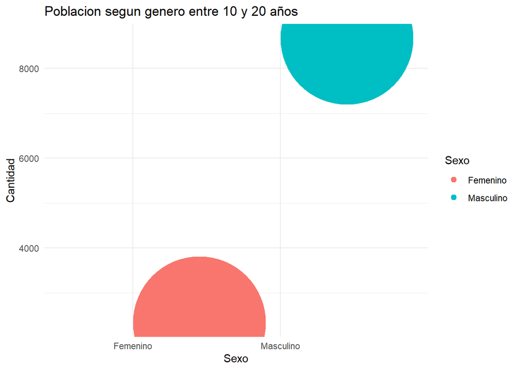

```r
respuesta_5_rango10y20 <- datos_totales_Tidy %>%
  filter(Edad >= 10 & Edad <= 20) %>%
  group_by(Sexo) %>%
  summarise(Cantidad = n())

respuesta_5_rango10y20 %>% ggplot(aes(x = Sexo, y = Cantidad, color = Sexo, fill = Sexo)) +
  geom_dots() +
  labs(title = "Poblacion segun genero entre 10 y 20 años") +
  theme_minimal()
```

```r
respuesta_5_rango10y20 <- datos_totales_Tidy %>%
  filter(Edad >= 10 & Edad <= 20) %>%
  filter(Respuestas == 5) %>%
  arrange(Preguntas) %>%
  group_by(Preguntas) %>%
  summarise(Cantidad = n())
respuesta_5_rango10y20
```

```
## # A tibble: 9 x 2
##   Preguntas                Cantidad
##   <chr>                       <int>
## 1 AccionarLento                 185
## 2 PensamientosSuicidas          277
## 3 PocoApetito                   489
## 4 PocoInteres                   304
## 5 ProblemasDeConcentracion      305
## 6 ProblemasDeSuenio             550
## 7 SensacionDeCansancio          559
## 8 SensacionDeDepresion          473
## 9 SensacionDeFracaso            476
```

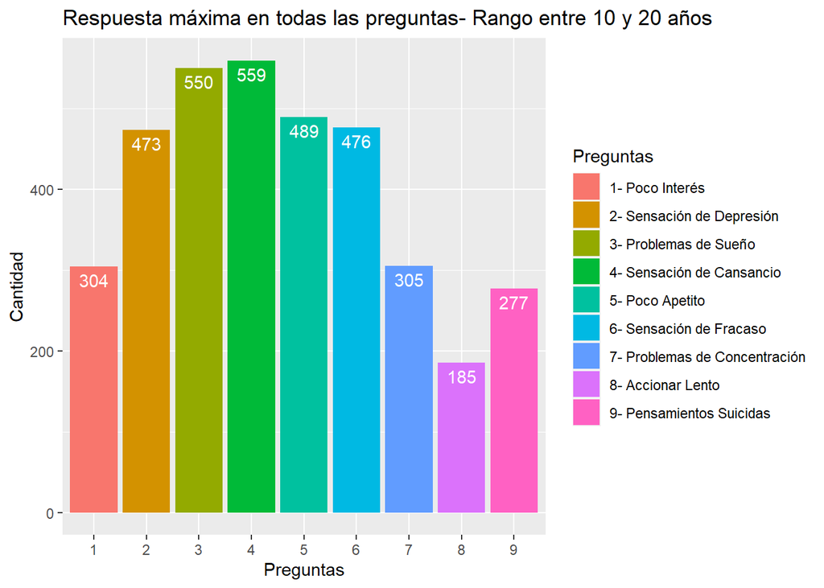

```r
respuesta_5_rango10y20$Preguntas <- factor(respuesta_5_rango10y20$Preguntas, levels = c("PocoInteres", "SensacionDeDepresion","ProblemasDeSuenio","SensacionDeCansancio", "PocoApetito", "SensacionDeFracaso", "ProblemasDeConcentracion", "AccionarLento", "PensamientosSuicidas"))

respuesta_5_rango10y20 %>% group_by(Preguntas) %>%   summarise(Cantidad = sum(Cantidad)) %>%   ggplot(aes(x = Preguntas, y=Cantidad, fill=Preguntas)) +
  ggtitle("Respuesta máxima en todas las preguntas- Rango entre 10 y 20 años") +
  geom_col() + scale_x_discrete(labels = c('1','2','3', '4', '5', '6', '7', '8', '9')) +
  scale_fill_discrete(labels = c('1- Poco Interés','2- Sensación de Depresión','3- Problemas de Sueño', '4- Sensación de Cansancio', '5- Poco Apetito', '6- Sensación de Fracaso', '7- Problemas de Concentración', '8- Accionar Lento', '9- Pensamientos Suicidas')) +
  geom_text(aes(label = Cantidad),  vjust = 1.5, colour = "white")
```

##Cantidad en funcion del genero para el rango entre 30 y 40 anios

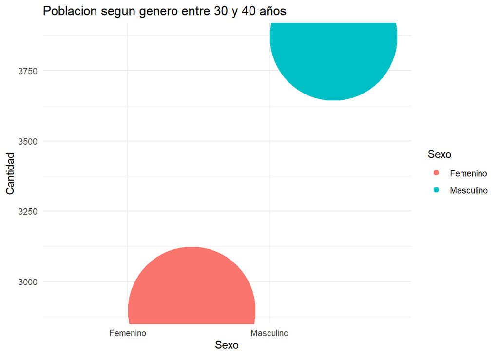

```r
respuesta_5_rango30y40 <- datos_totales_Tidy %>%
  filter(Edad >= 30 & Edad <= 40) %>%
  group_by(Sexo) %>%
  summarise(Cantidad = n())

respuesta_5_rango30y40 %>% ggplot(aes(x = Sexo, y = Cantidad, color = Sexo, fill = Sexo)) +
  geom_dots() +
  labs(title = "Poblacion segun genero entre 30 y 40 años") +
  theme_minimal()
```

```r
respuesta_5_rango30y40 <- datos_totales_Tidy %>%
  filter(Edad >= 30 & Edad <= 40) %>%
  filter(Respuestas == 5) %>%
  arrange(Preguntas) %>%
  group_by(Preguntas) %>%
  summarise(Cantidad = n()) #falta el calculo de freq relativa...
respuesta_5_rango30y40
```

```
## # A tibble: 9 x 2
##   Preguntas                Cantidad
##   <chr>                       <int>
## 1 AccionarLento                 116
## 2 PensamientosSuicidas          103
## 3 PocoApetito                   237
## 4 PocoInteres                   152
## 5 ProblemasDeConcentracion      176
## 6 ProblemasDeSuenio             281
## 7 SensacionDeCansancio          312
## 8 SensacionDeDepresion          221
## 9 SensacionDeFracaso            216
```

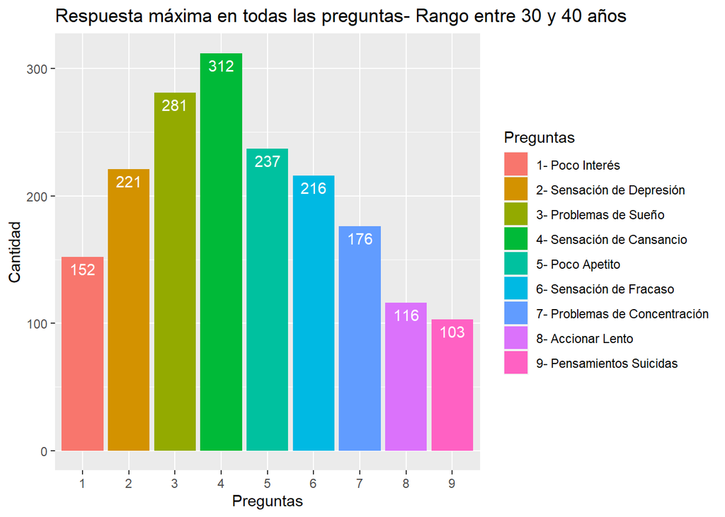

```r
respuesta_5_rango30y40$Preguntas <- factor(respuesta_5_rango30y40$Preguntas, levels = c("PocoInteres", "SensacionDeDepresion","ProblemasDeSuenio","SensacionDeCansancio", "PocoApetito", "SensacionDeFracaso", "ProblemasDeConcentracion", "AccionarLento", "PensamientosSuicidas"))


respuesta_5_rango30y40 %>% group_by(Preguntas) %>%   summarise(Cantidad = sum(Cantidad)) %>%   ggplot(aes(x = Preguntas, y=Cantidad, fill=Preguntas)) + ggtitle("Respuesta máxima en todas las preguntas- Rango entre 30 y 40 años") +
  geom_col() + scale_x_discrete(labels = c('1','2','3', '4', '5', '6', '7', '8', '9')) +
  scale_fill_discrete(labels = c('1- Poco Interés','2- Sensación de Depresión','3- Problemas de Sueño', '4- Sensación de Cansancio', '5- Poco Apetito', '6- Sensación de Fracaso', '7- Problemas de Concentración', '8- Accionar Lento', '9- Pensamientos Suicidas')) +
  geom_text(aes(label = Cantidad),  vjust = 1.5, colour = "white")
```

##Cantidad en funcion del genero para el rango entre 50 y 60 anios

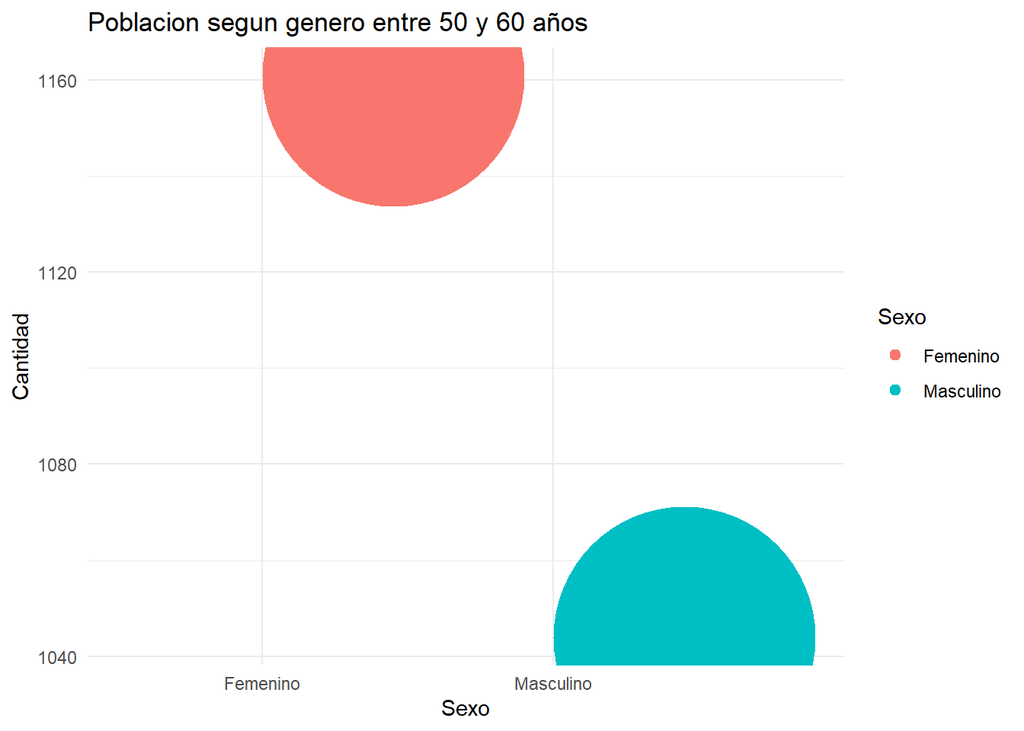

```r
respuesta_5_rango50y60 <- datos_totales_Tidy %>%
  filter(Edad >= 50 & Edad <= 60) %>%
  group_by(Sexo) %>%
  summarise(Cantidad = n())

respuesta_5_rango50y60 %>% ggplot(aes(x = Sexo, y = Cantidad, color = Sexo, fill = Sexo)) +
  geom_dots() +
  labs(title = "Poblacion segun genero entre 50 y 60 años") +
  theme_minimal()
```

```r
respuesta_5_rango50y60 <- datos_totales_Tidy %>%
  filter(Edad >= 50 & Edad <= 60) %>%
  filter(Respuestas == 5) %>%
  arrange(Preguntas) %>%
  group_by(Preguntas) %>%
  summarise(Cantidad = n()) #falta el calculo de freq relativa...
respuesta_5_rango50y60
```

```
## # A tibble: 9 x 2
##   Preguntas                Cantidad
##   <chr>                       <int>
## 1 AccionarLento                  35
## 2 PensamientosSuicidas           33
## 3 PocoApetito                    58
## 4 PocoInteres                    51
## 5 ProblemasDeConcentracion       43
## 6 ProblemasDeSuenio              65
## 7 SensacionDeCansancio           74
## 8 SensacionDeDepresion           55
## 9 SensacionDeFracaso             49
```

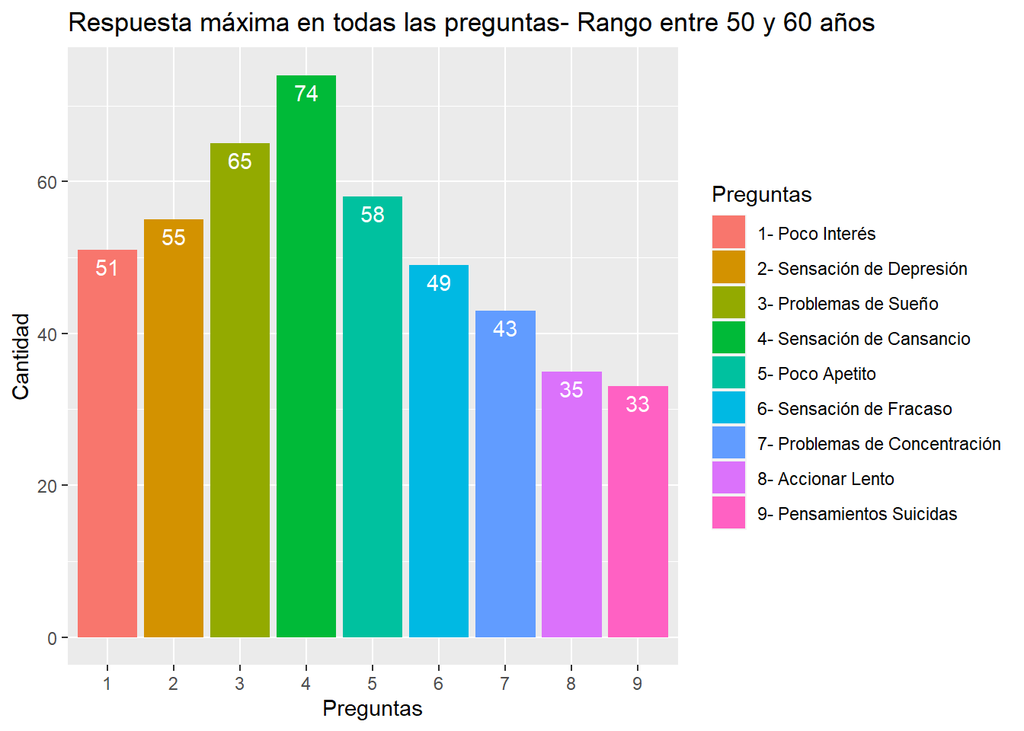

```r
respuesta_5_rango50y60$Preguntas <- factor(respuesta_5_rango50y60$Preguntas, levels = c("PocoInteres", "SensacionDeDepresion","ProblemasDeSuenio","SensacionDeCansancio", "PocoApetito", "SensacionDeFracaso", "ProblemasDeConcentracion", "AccionarLento", "PensamientosSuicidas"))


respuesta_5_rango50y60 %>% group_by(Preguntas) %>%   summarise(Cantidad = sum(Cantidad)) %>%   ggplot(aes(x = Preguntas, y=Cantidad, fill=Preguntas)) + ggtitle("Respuesta máxima en todas las preguntas- Rango entre 50 y 60 años") +
  geom_col() + scale_x_discrete(labels = c('1','2','3', '4', '5', '6', '7', '8', '9')) +
  scale_fill_discrete(labels = c('1- Poco Interés','2- Sensación de Depresión','3- Problemas de Sueño', '4- Sensación de Cansancio', '5- Poco Apetito', '6- Sensación de Fracaso', '7- Problemas de Concentración', '8- Accionar Lento', '9- Pensamientos Suicidas')) +
  geom_text(aes(label = Cantidad),  vjust = 1.5, colour = "white")
```

#—————————————————————————————— #MATRIZ DE CORRELACION #Hay un importante nivel de correlacion entre: #-La sensacion de depresion y el poco interes #-La sensacion de depresion y la sensacion de cansancio #-La sensacion de depresion y la sensacion de fracaso #-La sensacion de fracaso y los pensamientos suicidas #Relacion transitiva: Sensacion de depresion ->> Sensacion de fracaso ->> Pensamientos suicidas

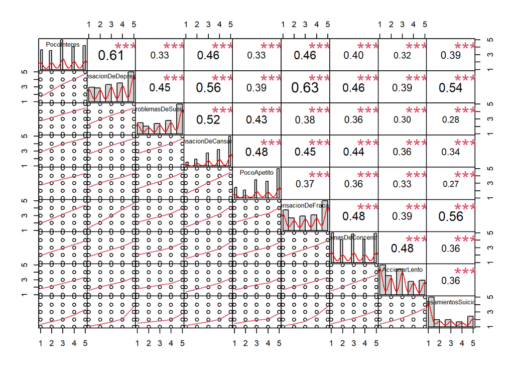

```r
rm(list = ls())

datos_totales <- read.csv("Base4900_on-line.csv", sep = ";", dec = ".", header = TRUE)
matriz <- datos_totales[,3:11]
cor <- cor(matriz)
cor2 <- chart.Correlation(matriz)
```

```r
#FALTA HACER UN MEJOR GRAFICO DE ESTO
```

#Matriz de correlacion entre Sensacion de depresion ->> Sensacion de fracaso ->> Pensamientos suicidas y Edad

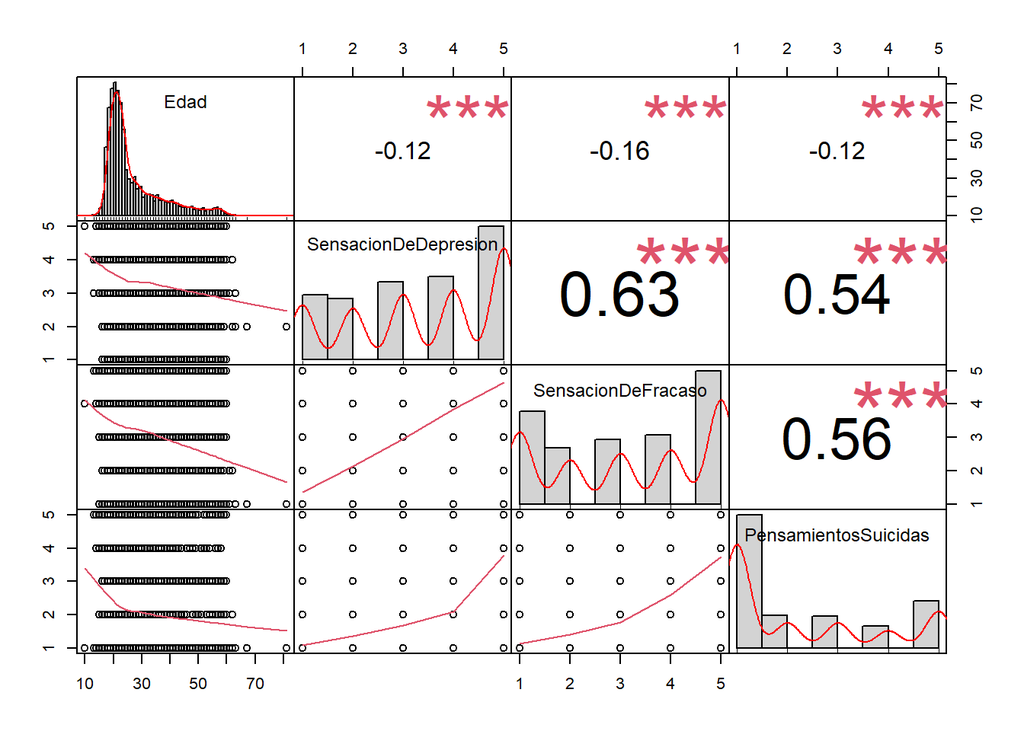

```r
#FILTRAR LAS COLUMNAS DEPRESION, FRACASO Y SUICIDIO Y CORRELACIONAR CON LA EDAD
datos_totales_reduccion <- read.csv("Base4900_v2.csv", sep = ";", dec = ".", header = TRUE)
matriz2 <- datos_totales_reduccion[,1:4]
cor <- cor(matriz2)
cor2 <- chart.Correlation(matriz2)
```

#—————————————————————————————— #PRUEBA t Y DATOS DESCRIPTIVOS

```r
rm(list = ls())
#Carga y preprocesado
Base <- read.csv("phq.csv", sep = ";", dec = ".", header = TRUE)


datos_Tidy <- Base %>%
  pivot_longer(c(phq1,phq2,phq3,phq4,phq5,phq6,phq7,phq8),names_to = "Preguntas", values_to = "Respuestas") %>%
   drop_na()
```

```r
#Prueba t y datos descriptivos


t.test(datos_Tidy$Respuestas ~ datos_Tidy$Suicide_extrem)
```

```
##
##  Welch Two Sample t-test
##
## data:  datos_Tidy$Respuestas by datos_Tidy$Suicide_extrem
## t = -81.268, df = 14799, p-value < 2.2e-16
## alternative hypothesis: true difference in means between group 0 and group 1 is not equal to 0
## 95 percent confidence interval:
##  -1.458499 -1.389800
## sample estimates:
## mean in group 0 mean in group 1
##        2.789043        4.213193
```

```r
datos_Tidy %>%
  group_by(Suicide_extrem) %>%
  summarise(mean(Respuestas,  na.rm = TRUE))
```

```
## # A tibble: 2 x 2
##   Suicide_extrem `mean(Respuestas, na.rm = TRUE)`
##            <int>                            <dbl>
## 1              0                             2.79
## 2              1                             4.21
```

```r
datos_Tidy %>%
group_by(Suicide_extrem, Preguntas) %>%
skim()
```

Data summary

| Name | Piped data |
| --- | --- |
| Number of rows | 26496 |
| Number of columns | 3 |
| _______________________ |  |
| Column type frequency: |  |
| numeric | 1 |
| ________________________ |  |
| Group variables | Suicide_extrem, Preguntas |

**Variable type: numeric**

| skim_variable | Suicide_extrem | Preguntas | n_missing | complete_rate | mean | sd | p0 | p25 | p50 | p75 | p100 | hist |
| --- | --- | --- | --- | --- | --- | --- | --- | --- | --- | --- | --- | --- |
| Respuestas | 0 | phq1 | 0 | 1 | 2.63 | 1.31 | 1 | 1 | 3 | 4 | 5 | ▇▆▇▅▃ |
| Respuestas | 0 | phq2 | 0 | 1 | 2.67 | 1.39 | 1 | 1 | 3 | 4 | 5 | ▇▆▆▅▃ |
| Respuestas | 0 | phq3 | 0 | 1 | 3.20 | 1.53 | 1 | 2 | 3 | 5 | 5 | ▆▃▅▅▇ |
| Respuestas | 0 | phq4 | 0 | 1 | 3.49 | 1.30 | 1 | 3 | 4 | 5 | 5 | ▂▅▆▆▇ |
| Respuestas | 0 | phq5 | 0 | 1 | 3.20 | 1.43 | 1 | 2 | 3 | 5 | 5 | ▆▃▇▆▇ |
| Respuestas | 0 | phq6 | 0 | 1 | 2.41 | 1.42 | 1 | 1 | 2 | 4 | 5 | ▇▃▃▃▂ |
| Respuestas | 0 | phq7 | 0 | 1 | 2.52 | 1.40 | 1 | 1 | 2 | 4 | 5 | ▇▅▅▃▃ |
| Respuestas | 0 | phq8 | 0 | 1 | 2.20 | 1.27 | 1 | 1 | 2 | 3 | 5 | ▇▃▅▂▂ |
| Respuestas | 1 | phq1 | 0 | 1 | 4.02 | 1.16 | 1 | 3 | 4 | 5 | 5 | ▁▁▃▃▇ |
| Respuestas | 1 | phq2 | 0 | 1 | 4.63 | 0.76 | 1 | 5 | 5 | 5 | 5 | ▁▁▁▂▇ |
| Respuestas | 1 | phq3 | 0 | 1 | 4.27 | 1.23 | 1 | 4 | 5 | 5 | 5 | ▁▁▁▂▇ |
| Respuestas | 1 | phq4 | 0 | 1 | 4.58 | 0.79 | 1 | 4 | 5 | 5 | 5 | ▁▁▁▂▇ |
| Respuestas | 1 | phq5 | 0 | 1 | 4.15 | 1.22 | 1 | 3 | 5 | 5 | 5 | ▁▁▂▂▇ |
| Respuestas | 1 | phq6 | 0 | 1 | 4.62 | 0.88 | 1 | 5 | 5 | 5 | 5 | ▁▁▁▁▇ |
| Respuestas | 1 | phq7 | 0 | 1 | 3.89 | 1.31 | 1 | 3 | 4 | 5 | 5 | ▁▂▃▃▇ |
| Respuestas | 1 | phq8 | 0 | 1 | 3.54 | 1.40 | 1 | 3 | 4 | 5 | 5 | ▃▂▆▃▇ |

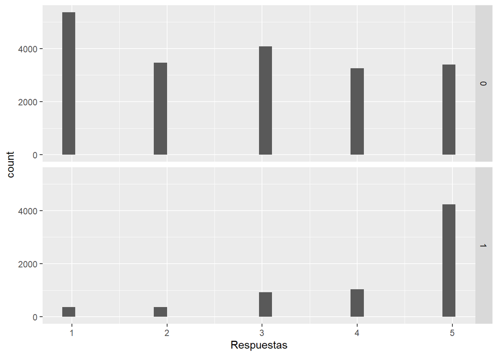

```r
#Graficas para el total de las preguntas sin diferenciar
datos_Tidy %>%
 mutate(Suicide_extrem = as.factor(Suicide_extrem)) %>%
ggplot(aes(x = Respuestas)) +
  geom_histogram() +
  facet_grid(Suicide_extrem ~ .)
```

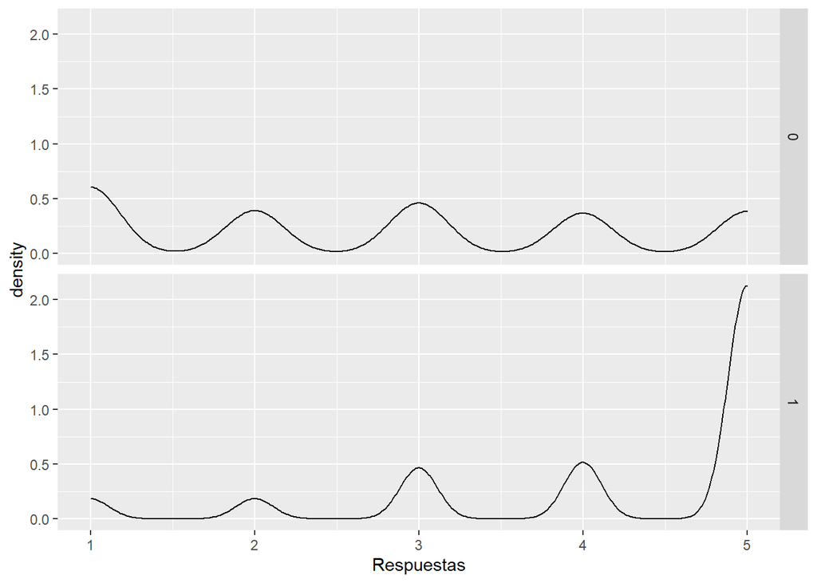

```r
datos_Tidy %>%
   mutate(Suicide_extrem = as.factor(Suicide_extrem)) %>%
ggplot(aes(x = Respuestas)) +
  geom_density() +
  facet_grid(Suicide_extrem ~ .)
```

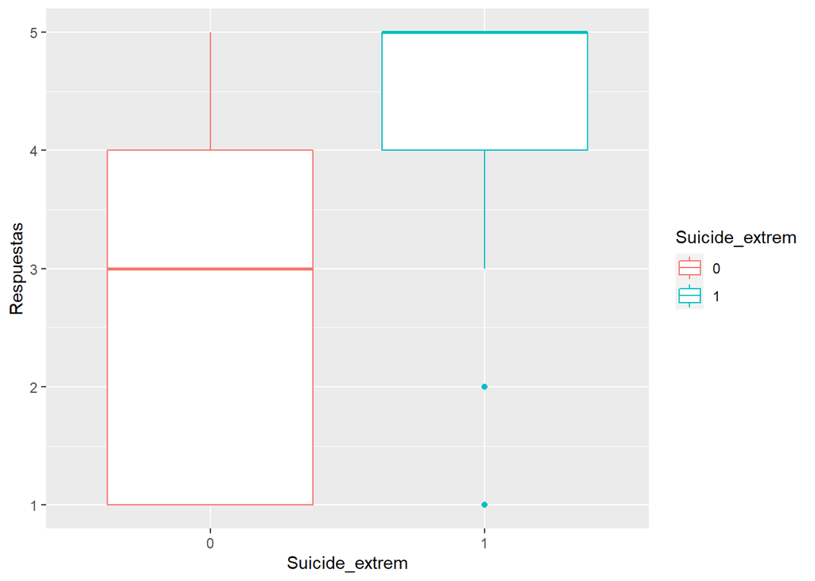

```r
datos_Tidy %>%
   mutate(Suicide_extrem = as.factor(Suicide_extrem)) %>%
  ggplot(aes(x = Suicide_extrem,
               y = Respuestas,
               color = Suicide_extrem)) +
  geom_boxplot()
```

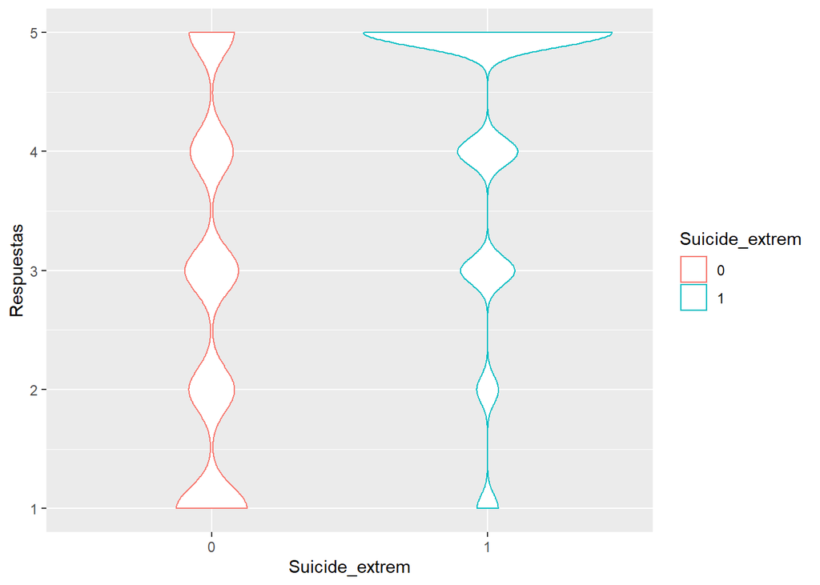

```r
datos_Tidy %>%
   mutate(Suicide_extrem = as.factor(Suicide_extrem)) %>%
  ggplot(aes(x = Suicide_extrem,
               y = Respuestas,
               color = Suicide_extrem)) +
  geom_violin()
```

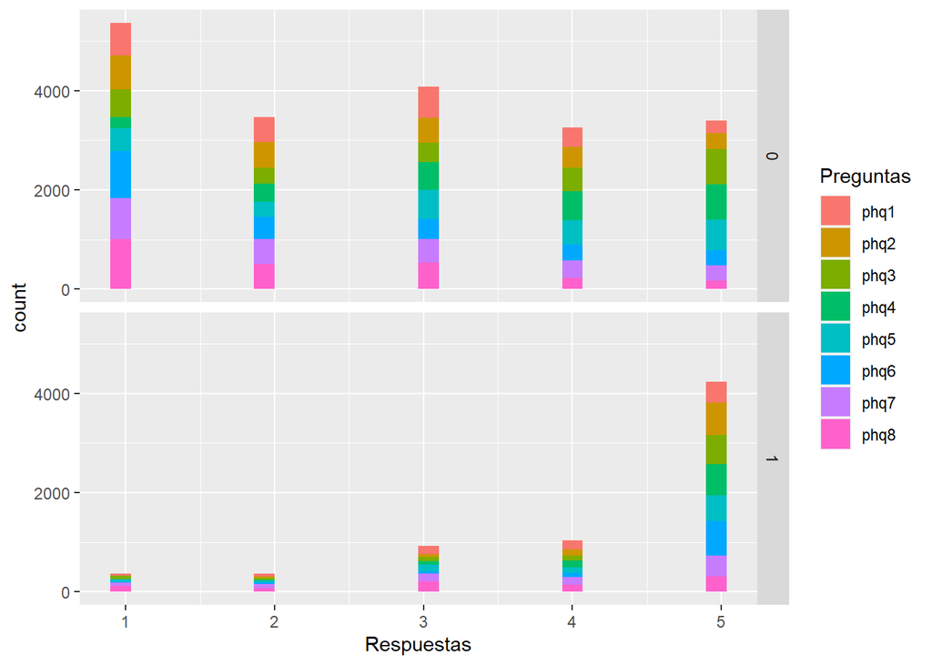

```r
#Graficas diferenciando las preguntas

datos_Tidy %>%
 mutate(Suicide_extrem = as.factor(Suicide_extrem)) %>%
ggplot(aes(x = Respuestas,
          fill = Preguntas)) +
  geom_histogram() +
  facet_grid(Suicide_extrem ~ .)
```

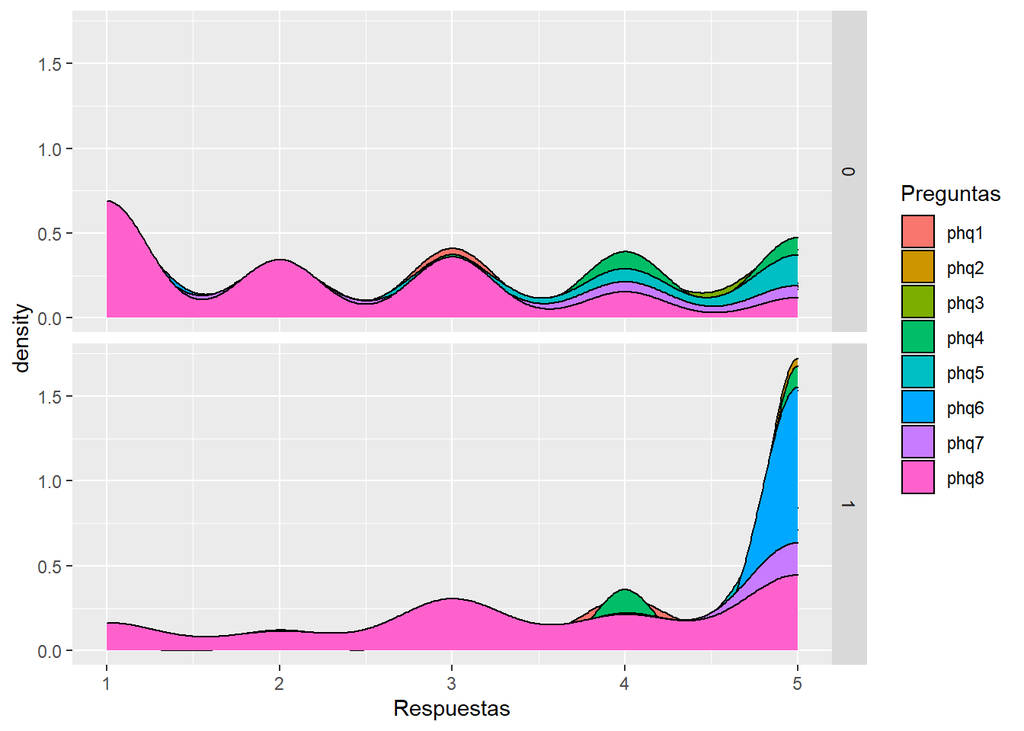

```r
datos_Tidy %>%
   mutate(Suicide_extrem = as.factor(Suicide_extrem)) %>%
ggplot(aes(x = Respuestas,
       fill = Preguntas)) +
  geom_density() +
  facet_grid(Suicide_extrem ~ .)
```

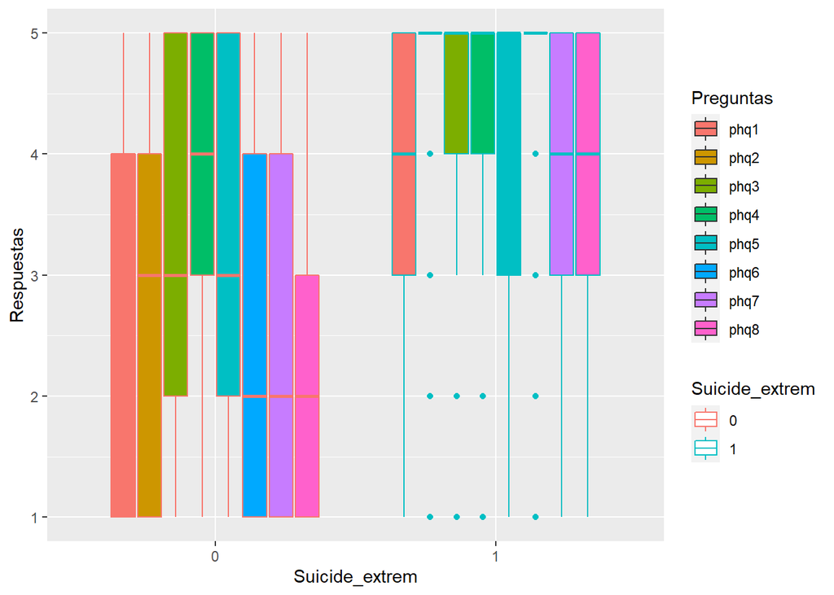

```r
datos_Tidy %>%
   mutate(Suicide_extrem = as.factor(Suicide_extrem)) %>%
  ggplot(aes(x = Suicide_extrem,
               y = Respuestas,
              fill = Preguntas,
             color = Suicide_extrem)) +
  geom_boxplot()
```

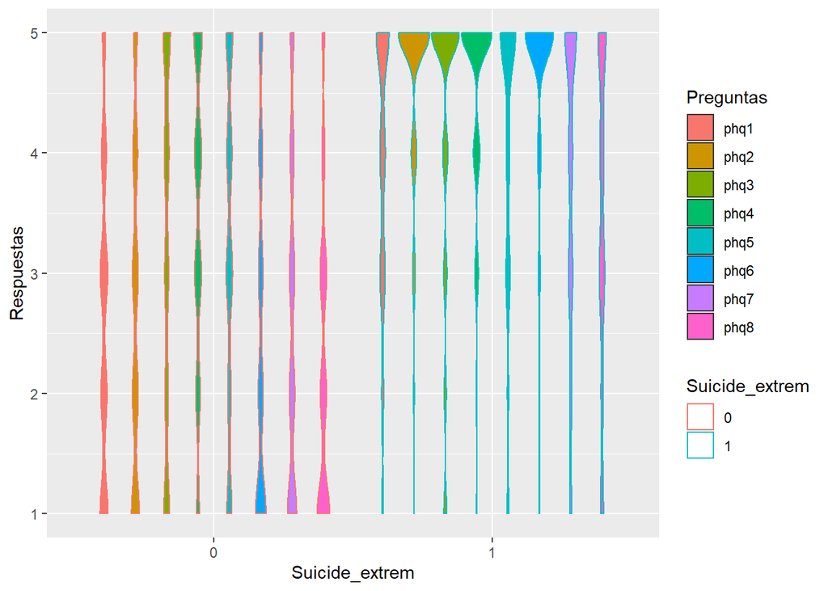

```r
datos_Tidy %>%
   mutate(Suicide_extrem = as.factor(Suicide_extrem)) %>%
  ggplot(aes(x = Suicide_extrem,
               y = Respuestas,
              fill = Preguntas,
             color = Suicide_extrem)) +
  geom_violin()
```

## ——————————————————————————-

## ESTIMACION Y COMPARACIÓN DE LOS MODELOS DE REDES

## 1. Bases de Datos modificada. Se agrega columna Suicide-Extrem ya categorizada.

```r
Base <- read.csv("phq.csv", sep = ";", dec = ".", header = TRUE)


suicide <- Base[Base$Suicide_extrem == 1, ]
non_suicide <- Base[Base$Suicide_extrem == 0, ]

data_suicide <- suicide[2:9]
data_nonsuicide <- non_suicide[2:9]

data_suicide <- na.omit(data_suicide)
data_nonsuicide <- na.omit(data_nonsuicide)
```

## 3. Estimacion de Redes

```r
Network_suicide <- estimateNetwork(data_suicide,
                                 default = "EBICglasso",
                                 corMethod = "spearman")
```

```
## Estimating Network. Using package::function:
##   - qgraph::EBICglasso for EBIC model selection
##     - using glasso::glasso
```

```r
Network_non_suicide <- estimateNetwork(data_nonsuicide,
                                   default = "EBICglasso",
                                   corMethod = "spearman")
```

```
## Estimating Network. Using package::function:
##   - qgraph::EBICglasso for EBIC model selection
##     - using glasso::glasso
```

```
## Note: Network with lowest lambda selected as best network: assumption of sparsity might be violated.
```

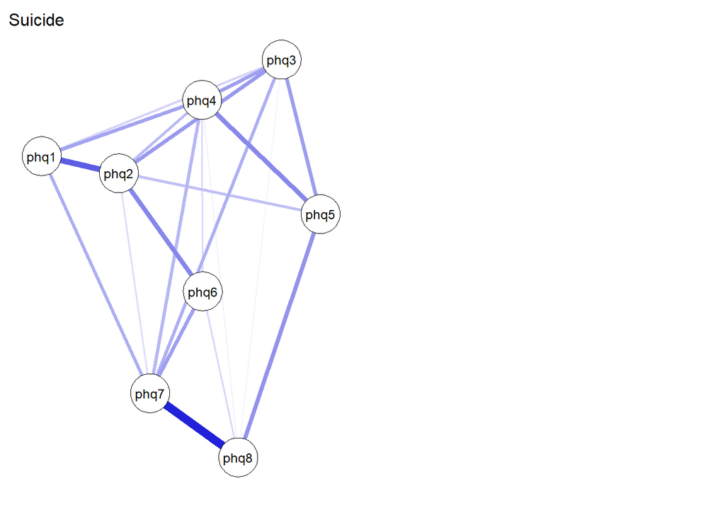

```r
L <- averageLayout(Network_suicide, Network_non_suicide)
Max <- max(abs(c(getWmat(Network_suicide), getWmat(Network_non_suicide))))
layout(t(1:2))
plot(Network_suicide, layout = L, title = "Suicide", maximum = Max)
```

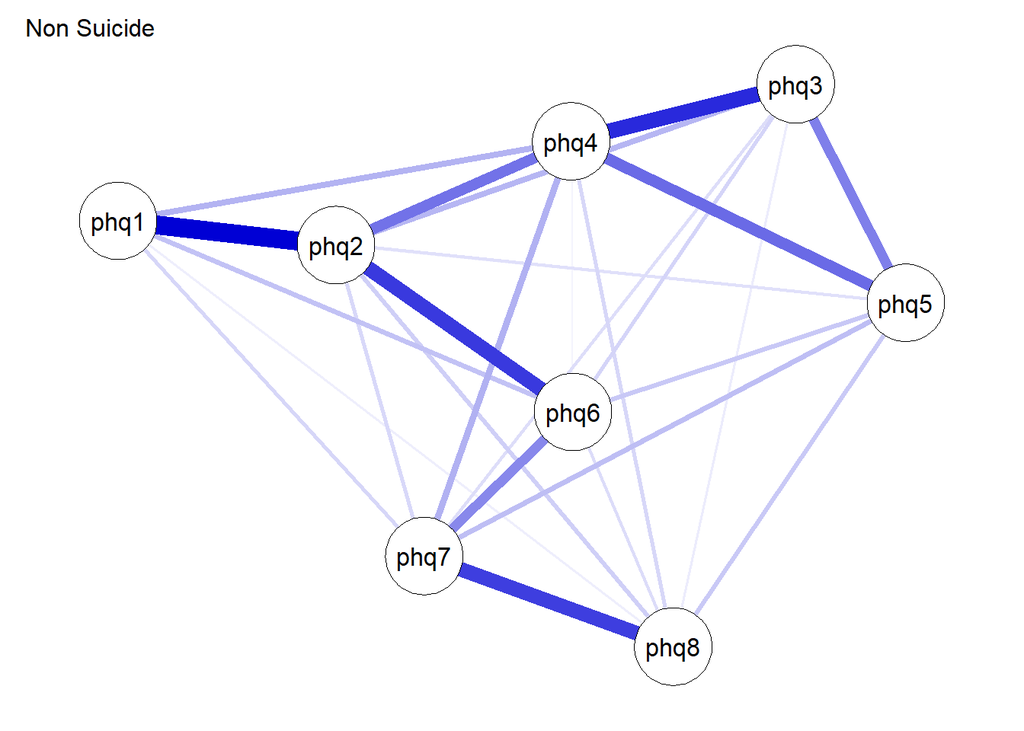

```r
plot(Network_non_suicide, layout = L, title = "Non Suicide", maximum = Max)
```

## 4. Test de Comparación de Redes

```r
set.seed(1)
NCTres <- NCT(data_suicide, data_nonsuicide,
              it=100,
              test.edges = TRUE,
              progressbar= FALSE,
              edges = "all",
              p.adjust.methods = "bonferroni")

summary(NCTres)
```

```
##
##  NETWORK INVARIANCE TEST
##       Test statistic M:  0.1702019
##  p-value 0
##
##  GLOBAL STRENGTH INVARIANCE TEST
##       Global strength per group:  2.487601 3.171567
##  Test statistic S:  0.6839659
##  p-value 0
##
##  EDGE INVARIANCE TEST
##       Edges tested:
##  Test statistic E:  0 0.1683128 0.07690371 0.04806221 0.05725367 0.09366271 0.04144196 0.02943181 0.1683128 0 0.008141929 0.07379801 0.009249531 0.08353979 0.00481754 0.05941067 0.07690371 0.008141929 0 0.1702019 0.04318059 0.05203853 0.08866734 0.01035627 0.04806221 0.07379801 0.1702019 0 0.0787…
##  p-value 0 0.56 1 1 1 0 1 1 1 1 0.84 0.84 1 1 1 1 1 0.84 1 1 1 1 1 1 1 1 1 1
##
##  CENTRALITY INVARIANCE TEST
##       Nodes tested:
##  Centralities tested:
##  Test statistic C:
##  p-value
```

```r
NCTres$einv.pvals[which(NCTres$einv.pvals[,3] < 0.05), ]
```

```
##    Var1 Var2 p-value
## 9  phq1 phq2       0
## 27 phq3 phq4       0
```